# Passey model report

Sarah Pederzani

### Model Information

Project: Axlor Inverse Model reruns

Tooth ID: AXL70

Model run date: 2021-11-18

### Emeas

Emeas input parameters:

```
## $numtrials
## [1] 100
##
## $r1
## [1] 0.25
##
## $r2
## [1] 1
##
## $r3
## [1] 2
##
## $la
## [1] 15
```

notes:

numtrials - number of trials to run iteration  
numsam - number of isotope samples/values  
r1 - (real) isotope 1 sigma reproducibility  
r2 - (integer) sample length 1 sigma reproducibility (in mm * 10)  
r3 - (integer) sample depth 1-sigma reproducibility (in mm * 10)  
la - (integer) length of apposition (in mm * 10)

Emeas output:

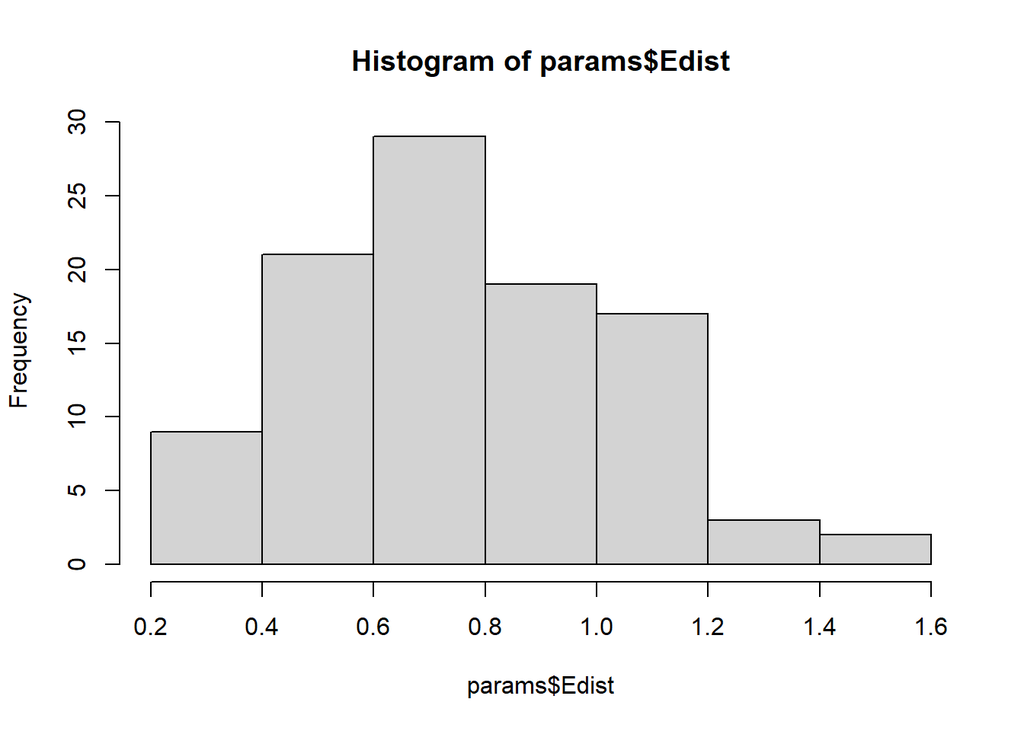

mean(E<sub>meas</sub>) = 0.77

note: Edist is a vector of estimated measurement error (E<sub>meas</sub>) for each trial

### mSolv

mSolv input parameters:

```
## $nsolxns
## [1] 100
##
## $openindx
## [1] 1
##
## $lm
## [1] 250
##
## $la
## [1] 15
##
## $finit
## [1] 0.25
##
## $maxlength
## [1] 40
##
## $minlength
## [1] 2
##
## $mindepth
## [1] 5
##
## $r1
## [1] 0.25
##
## $r2
## [1] 1
##
## $r3
## [1] 2
##
## $maxratio
## [1] 17
##
## $minratio
## [1] 15
##
## $stdev
## [1] 0.5
##
## $df
## [1] 0.015
```

notes:

nsolxns - number of solutions to be computed  
openindx - degree of openendedness, less than lm, openended (profile mature) –> index = 1; close ended (enamel immature) index = lm  
lm - length of maturation  
la - (integer) length of apposition (in mm * 10)  
finit - volumetric fraction of mineral in immature enamel compared to mature enamel  
maxlength - maximum sampling length  
minlength - minimum sampling length (must be > 2)  
mindepth - minumum sampling depth  
r1 - (real) isotope 1 sigma reproducibility  
r2 - (integer) sample length 1 sigma reproducibility (in mm * 10)  
r3 - (integer) sample depth 1-sigma reproducibility (in mm * 10)  
maxratio - max value of the generated reference vector (choose close to average of actual isotope value)  
minratio - min value of the generated reference vector (choose close to average of actual isotope value)  
stdev - sd for random draws that produce reference vector  
df - damping factor. Needs to be chosen to minimize difference between the estimated measurement error (E<sub>meas</sub>) and the prediction error (E<sub>pred</sub>)

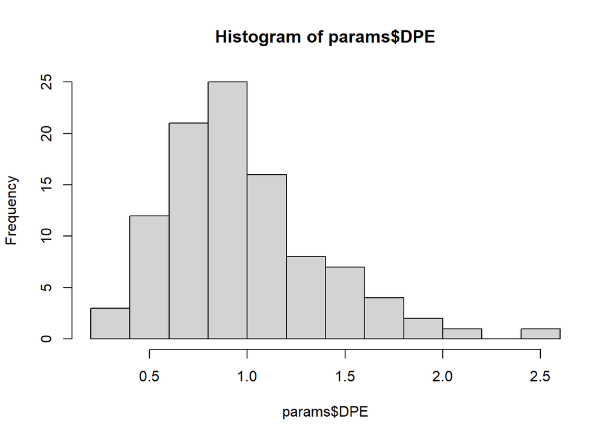

mean(E<sub>pred</sub>) = 0.98

note: DPE is a vector of prediction error (E<sub>pred</sub>) for each trial. It should be close to E<sub>meas</sub>